# sp_33__gl

## Групове заняття № 19

### *Тема 5:* Машинне навчання без учителя / Unsupervised machine learning

### *Заняття 33:* Кластеризація даних методом Principial Component Analysis

Обговорена та ухвалена на засіданні кафедри інформаційних технологій та кібербезпеки 21 серпня 2026 р., протокол № 01

### Результати заняття

*(слухач зможе)*

1. Пояснити суть методу **Principial Component Analysis**.
2. Застосувати лінійні перетворення для масштабування колекції даних, обчислити коваріаційну матрицю, власні вектори та власні значення, а також спроєктувати реальний багатовимірний набір даних на обрані головні компоненти з оцінкою частки поясненої варіативності.

**Навчальний час**: 2 години.

### ПЛАН ЗАНЯТТЯ

| № | Навчальні питання | Час, хв |
| --- | --- | --- |
| 1 | **ВСТУПНА ЧАСТИНА** Організаційні питання | 5 |
| 2 | **ОСНОВНА ЧАСТИНА** | 80 |
|  | 1. Теоретичні основи методу PCA | 40 |
|  | 2. Підходи до практичної реалізації методу PCA | 40 |
| 3 | **ЗАКЛЮЧНА ЧАСТИНА** | 5 |
|  | Порядок оцінювання |  |
|  | Завдання на самостійну підготовку |  |
|  | Питання для самоконтролю |  |

### **ВСТУПНА ЧАСТИНА**

Організаційні питання.

### **ОСНОВНА ЧАСТИНА**

### 1. Теоретичні основи методу PCA

Запропонований метод дозволяє спробувати впорядкувати дані, які описані значною кількістю ознак.  
По суті даний метод дозволяє вирішити наступні завдання:

- зменшити кількість ознак, які необхідно опрацьовувати, причому ці ознаки можуть бути похідними від базового набору;
- визначити, які із них є найбільш значимими.

Вирішення проблеми значної кількості ознак обумовлена і тим, що двовимірні чи тривимірні дані можна відобразити на графіку, та зрозуміти тенденції. У випадку більшої кількості - це вже не є можливим. Коли зменшено кількість ознак, такий набір може бути опрацьований іншим алгоритмом.

Слід відзначити, що інші ознаки не відкидаються, а трансформуються

При підході із розміченими даними є можливість відзначити серед набору ознаки, які більше впливають на цільову змінну.

Одним із понять, яке застосовується у даному методі, є **варіативність ознак** (`variance explained`). Тобто, як кожна окрема ознака впливає на розсіювання даних.

Приклад

Нехай є набір об'єктів із двома ознаками: *зріст* (см) та *вага* (кг). Якщо всі об'єкти мають майже однаковий зріст, але суттєво відрізняються за вагою, то дисперсія (варіативність) ознаки "вага" буде значно більшою за дисперсію ознаки "зріст". Це означає, що саме вага більше "розповідає" про відмінності між об'єктами, а отже є більш інформативною ознакою з точки зору розсіювання даних.

Розглянемо приклад, нехай є дві ознаки, які мають наступний розподіл

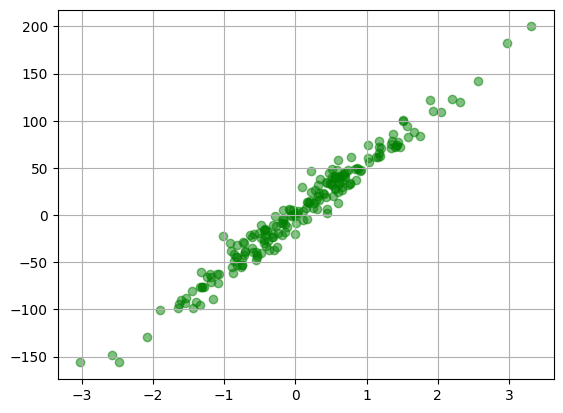

Рис. 1.1

Це є відображенням значень у відповідних вимірах ознак. Можна ввести інший вимір (*синя вісь*) у якому значення відображатимуться наступним чином

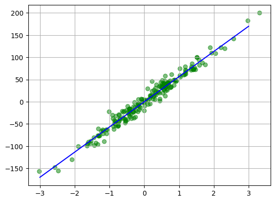

Рис. 1.2

Доповнивши ще однією ортогональною віссю (*червона*)

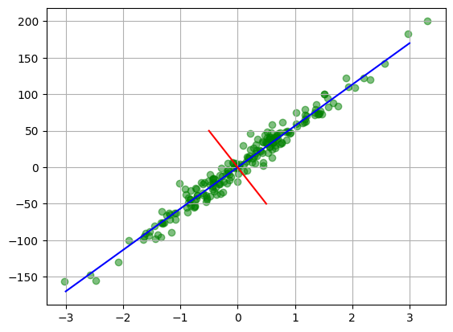

Рис. 1.3

та проаналізувавши дані, приймемо допущення, що у вимірі червоної осі дані варіюються не суттєво. А тому можемо їх описати як проекції на створений вимір (*синя вісь*). Це дозволить зменшити розмірність ознак, а отримана вісь - буде головним компонентом 1 (`principal component 1`).

Анімація реалізації

Нижче наведено анімовану реалізацію описаного процесу: спочатку система координат переноситься у геометричний центр даних, а потім повертається до напрямку найбільшої варіативності — осі головного компонента 1.

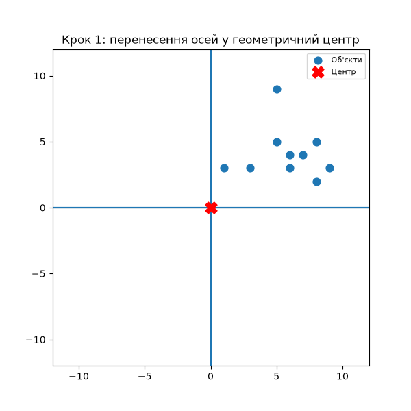

Рис. 1.3.1 Анімація центрування та повороту осей

🎯 **Головний компонент** - це лінійна комбінація із первинних ознак (*кількох чи усіх*), які описують об'єкт у масиві даних. Їх може бути від одного і більше, головна ціль - зменшити розмірність ознак.

[figure not shown]

Рис. 1.4

При цьому втрачається частина інформації, але тенденції у даних залишаються.  
По суті створюються нові ознаки, які іменуються *головні компоненти*, і описують об'єкти у нових (трансформованих) вимірах.  
Математично розглянутий приклад (рис.1.1-1.3) можна записати наступним чином

$𝑍1=𝑘11𝑋1+𝑘21𝑋2$

що дозволяє отримати із двох вимірів ($𝑋1$, $𝑋2$) -> один, $𝑍1$.

Приклад обчислення

Нехай коефіцієнти головного компонента дорівнюють $𝑘11 =0.7$, $𝑘21 =0.7$ (приблизно $1/√2$ — поворот осей на 45°), а об'єкт має значення ознак $𝑋1 =4$, $𝑋2 =6$. Тоді  
$𝑍1=0.7⋅4+0.7⋅6=2.8+4.2=7$Отримане число $𝑍1 =7$ — це нова "координата" об'єкта вздовж головного компонента, яка одночасно враховує внесок обох вихідних ознак.

#### 🧠Практичне завдання 1

> Розробити код програми, що дозволяє:
> 1. Генерувати дані, які складаються із 10 об'єктів, кожен із яких має по дві числові ознаки. Ознаки згенерувати на основі випадкових значень.
> 2. Побудувати двомірний графік, що відображає об'єкти у просторі ознак.
> 3. Визначити геометричний центр ознак та відобразити на графіку.
> 4. Перенести осі координат у центр (геометричний) ознак - трансформувати дані та відобразити їх у новій системі координат на графіку.

> TechStack: python;numpy,matplotlib;  
> Макс. бал: 1.2 / Час, хв: 20

Для генерування послідовності використати наступний код

```python
import random
# номер за списком у журналі групи
number_in_journal = 12
random.seed(number_in_journal)
data = [random.randint(1, 10) for _ in range(10)]
print(data)
```

### 2. Підходи до практичної реалізації методу PCA

*Теорія - 20 хв, практика - 20 хв*

Створення нових ознак, як лінійних перетворень початкових, спрямовується на зменшення вихідної розмірності даних. У попередньому практичному занятті розглянуто підходи щодо позиціювання системи вимірів ознак у їх геометричному центрі.  
Це стосувалося окремих значень, але лінійні перетворення справедливі і для векторів. Розглянемо це на графіку

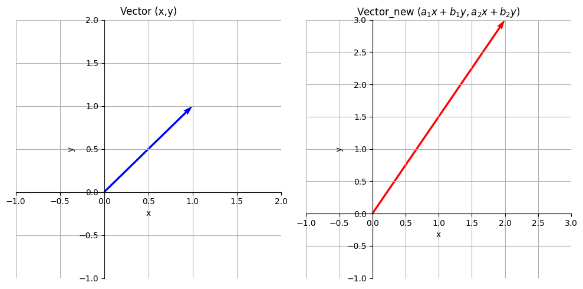

Рис. 2.1

Після лінійного перетворення вектор може мати інший модуль (довжину) та напрям. У випадку коли напрям вектору після перетворення залишається без змін, у лінійній алгебрі його називають - **власний вектор** (*Eigen Vector*).  
Модуль такого вектору обчислюється по теоремі Піфагора.  
Лінійне перетворення власних векторів виконується з використанням [коваріаційної матриці](https://uk.wikipedia.org/wiki/%D0%9A%D0%BE%D0%B2%D0%B0%D1%80%D1%96%D0%B0%D1%86%D1%96%D0%B9%D0%BD%D0%B0_%D0%BC%D0%B0%D1%82%D1%80%D0%B8%D1%86%D1%8F).

$[𝐷𝑥1𝑐𝑜𝑣(𝑥1,𝑥2)𝑐𝑜𝑣(𝑥2,𝑥1)𝐷𝑥2]$

Властивості:

- квадратна матриця
- діагональ - містить [дисперсії](https://uk.wikipedia.org/wiki/%D0%94%D0%B8%D1%81%D0%BF%D0%B5%D1%80%D1%81%D1%96%D1%8F_%D0%B2%D0%B8%D0%BF%D0%B0%D0%B4%D0%BA%D0%BE%D0%B2%D0%BE%D1%97_%D0%B2%D0%B5%D0%BB%D0%B8%D1%87%D0%B8%D0%BD%D0%B8) випадкових величин
- інші елементи - попарні [коваріації](https://uk.wikipedia.org/wiki/%D0%9A%D0%BE%D0%B2%D0%B0%D1%80%D1%96%D0%B0%D1%86%D1%96%D1%8F) між випадковими величинами

Приклад коваріаційної матриці

Нехай для двох ознак $𝑋1$ (зріст) та $𝑋2$ (вага) після центрування обчислено: $𝐷𝑥1 =4$, $𝐷𝑥2 =9$, $𝑐𝑜𝑣(𝑥1,𝑥2) =3$. Тоді коваріаційна матриця має вигляд:  
$[4339]$Додатна коваріація ($𝑐𝑜𝑣 =3 >0$) свідчить, що ознаки змінюються узгоджено: зі зростанням зросту частіше зростає і вага.

Власний вектор має *власне значення* - що є числом, що кількісно вказує на зміну (масштабування) модуля власного вектора у ході лінійного перетворення.  
Власні значення векторів описують частку певної ознаки об'єкта у зміні його загальної поведінки - **варіативності даних**.

Обчисливши значення головних компонент, та оцінивши їх власні значення, обирають найбільш суттєві для подальшої роботи із ними щодо вивчення тенденцій.  
Враховуючи вищезазначене, алгоритм методу наступний:

- завантаження та формування датафрейму
- розрахунок коваріаційної матриці
- розрахунок власних векторів
- сортування по величині значення власного вектору
- відбір заданої кількості власних значень векторів
- проектування на ці вектори значень датафрейму

#### 🧠Практичне завдання 2

> Розробити код програми, що дозволяє:
> 1. Завантажити набір даних та стандартизувати (масштабувати) числові ознаки.
> 2. Розрахувати коваріаційну матрицю стандартизованих ознак.
> 3. Обчислити власні вектори та власні значення цієї матриці, відсортувати їх за величиною.
> 4. Відібрати власні вектори, що відповідають 3-му та 4-му головним компонентам (а не найбільшим PC1, PC2), та спроєктувати на них дані.
> 5. Обчислити й вивести частку варіативності, яку пояснюють обрані компоненти.

> набір даних для роботи — 569 об'єктів, 30 числових ознак (середні значення, похибки та "найгірші" значення радіусу, текстури, периметру, площі тощо), отриманих із цифрових зображень

> TechStack: python;pandas,numpy,scikit-learn;  
> Макс. бал: 1.2 / Час, хв: 20

### **ЗАКЛЮЧНА ЧАСТИНА**

#### Завдання на самостійну підготовку

1. Опрацювати питання, що були розглянуті на лекційному та груповому заняттях.
2. Пройти тести для самоконтролю.
3. Опрацювати документацію щодо використання `sklearn.decomposition.PCA` для автоматизованого розрахунку головних компонентів.

#### Питання для самоконтролю

1. У чому полягає мета застосування методу PCA?
2. Що таке варіативність ознак (variance explained) і яку роль вона відіграє у методі?
3. Що таке власний вектор та власне значення коваріаційної матриці?
4. Які кроки включає алгоритм методу PCA?

### Порядок оцінювання

Відповідно до РПНД на груповому занятті слухач може отримати максимально **4 бали** за 100-бальною шкалою оцінювання даної дисципліни. При цьому:

- за контрольне опитування — **1.6 балів**,
- за виконання практичних завдань — **2.4 бали**.

Контрольне опитування складається з 8 тестових питань, неправильна / відсутня відповідь на питання тесту знижує загальний бал на **0.2**.

При виконанні практичних завдань нарахування балів розподіляється наступним чином:

| **практичне завдання** | **бали** |
| --- | --- |
| 1 | 1.2 |
| 2 | 1.2 |
| **Всього** | **2.4** |

За порушення академічної доброчесності за рішенням викладача може бути знято до 0,5 балів.

Виставлення оцінок в журнал успішності за національною шкалою проводиться за критеріями, що визначені у таблиці:

| **Оцінка** | **5** | **4** | **3** | **2** |
| --- | --- | --- | --- | --- |
| Кількість балів | [4;3.6] | (3.6;2.6] | (2.6;2.0] | (2.0;0] |